# Class Notes - Day 7

Charlie Hall

10/27/2020

### Review

Recall that we used t-dist with df = n-1 = 29 for sampling dist of the sample mean last time

- As $n>25$, we know the sampling dist of the sample mean will follow a normal dist with mean $\mu$ and std dev $\sigma/\sqrt{n}$
- in our example, sigma was unknown, so we used sample standard dev S instead
- so, our dist follows t-dist

Bootstrap dist has same shape/spread/variance/dev as sampling dist. Only difference is where it is centered (around x-bar)

#### Run appropriate statistical test using bootstrap dist to test whether true mean is greater than 52k

$H_{0}:\mu = 52000$ vs $H_{a}:\mu > 52000$

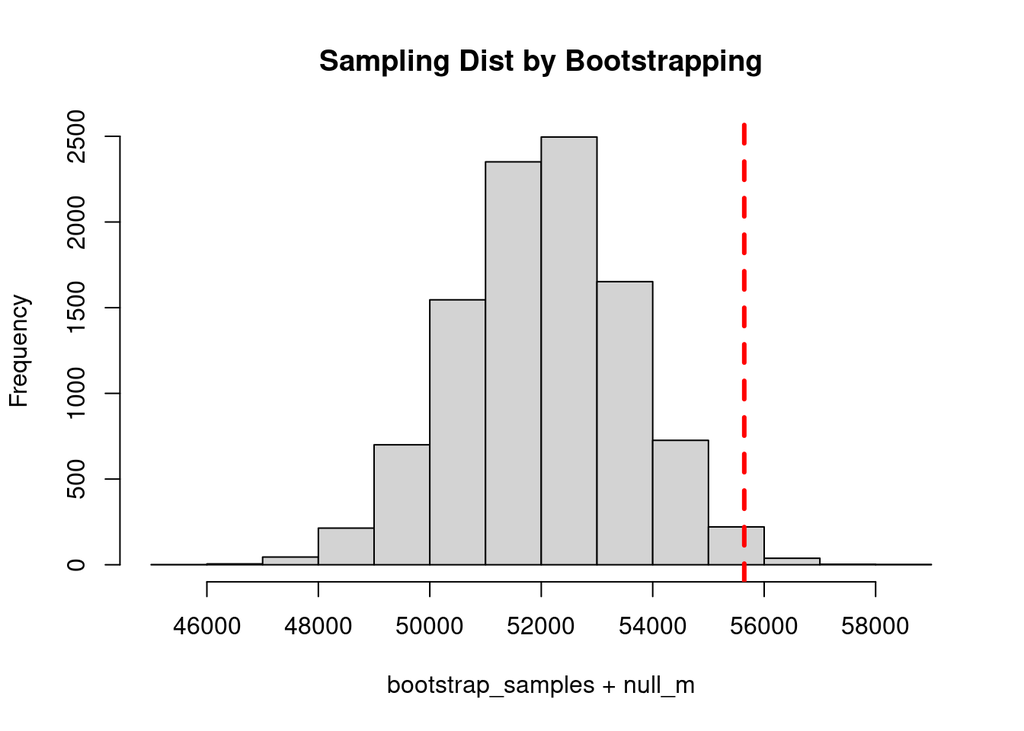

```r
x_2 <- c(58899, 58523, 69163, 51585, 65461, 49414,
         54244, 64756, 37196, 64313, 61720, 52986,
         48764, 55008, 41069, 49605, 48639, 51568,
         49855, 64049, 57960, 57046, 45702, 68603,
         55967, 59273, 65077, 55281, 39603, 67960)

our_s_m <- mean( x_2 )

null_m <- 52000

bootstrap_samples <- rep(0,10000)
for(i in 1:10000) {
  bootstrap_samples[i] <- mean( sample(x_2 - our_s_m, length(x_2), replace = TRUE))
}

hist( bootstrap_samples + null_m,
      main = 'Sampling Dist by Bootstrapping')

abline(v = our_s_m, col = 'red', lty = 2, lwd = 3)
```

```r
(p_value <- mean( bootstrap_samples + null_m > our_s_m))
```

```
## [1] 0.0093
```

```r
t.test(x_2, alternative = 'greater', mu = 52000)
```

```
##
##  One Sample t-test
##
## data:  x_2
## t = 2.3175, df = 29, p-value = 0.01387
## alternative hypothesis: true mean is greater than 52000
## 95 percent confidence interval:
##  52972.06      Inf
## sample estimates:
## mean of x
##  55642.97
```

### Resampling

So far, we have learned concept of **bootstrap resampling**.

- by resampling with replacement from our sample, we created bootstrap dist.

Another resampling method is **permutation resampling**.

- testing between 2 or more groups (e.g. A/B test)
- nonparametric method (no assumptions about dists)
- permutation test: randomization test, random permutation test, exact test
- we use resampling **without replacement** for permutation test

```r
session_times <- read_csv("~/Downloads/session_times.csv")
knitr::kable(session_times[1:5,])
```

| Page | Time |
| --- | --- |
| Page A | 21 |
| Page B | 253 |
| Page A | 35 |
| Page B | 71 |
| Page A | 67 |

A/B Test: total of 36 sessions.

- longer session time –> attention longer –> more sales
- 21 sessions for page A
- 15 sessions for page B

We would like to test whether page B generates longer session time.

- $H_{0}: \mu_{b} = \mu_{a}$ vs. $H_{a}: \mu_{b} > \mu_{a}$

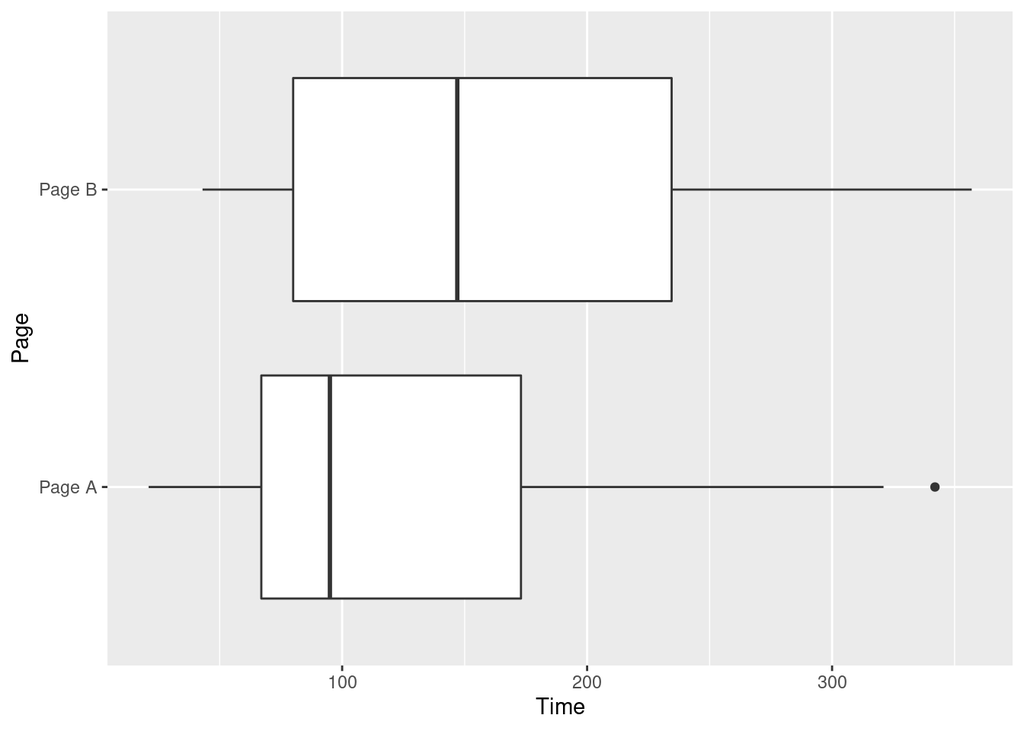

```r
session_times %>% ggplot(aes(Time, Page)) +
  geom_boxplot()
```

```r
(avg_T_AB <- session_times %>% group_by( Page ) %>%
    summarize( avg_T = mean( Time )))
```

```
## # A tibble: 2 x 2
##   Page   avg_T
##   <chr>  <dbl>
## 1 Page A  126.
## 2 Page B  162
```

```r
avg_T_AB$avg_T[avg_T_AB$Page == 'Page B'] -
  avg_T_AB$avg_T[avg_T_AB$Page == 'Page A']
```

```
## [1] 35.66667
```

**2-Sample T Test** is popular for testing this type of hypothesis.

- only 21 sessions for page A –> too small sample size
- only 15 sessions for page B –> too small sample size
- we need at least n > 25 or n > 30 if we want to be conservative

```r
t.test(session_times$Time[session_times$Page == 'Page B'],
       session_times$Time[session_times$Page == 'Page A'],
       alternative = 'greater')
```

```
##
##  Welch Two Sample t-test
##
## data:  session_times$Time[session_times$Page == "Page B"] and session_times$Time[session_times$Page == "Page A"]
## t = 1.0983, df = 27.693, p-value = 0.1408
## alternative hypothesis: true difference in means is greater than 0
## 95 percent confidence interval:
##  -19.59674       Inf
## sample estimates:
## mean of x mean of y
##  162.0000  126.3333
```

p-value > 0.05: not rare!

- As probability of getting our sample or more extreme ones is not rare (aka common), null hypo seems to be ok.
- conclusion: do not reject $H_{0}$.
- interp: no evidence to support $H_{a}$
  - we found no evidence from sample data to support claim that page B generates longer session time than page A on avg.

**Perm. Resampling with Session Times**

If null hypo is true, we can treat current sample as a particular realization of random sampling from 36 time values, rather than taking page into account.

```r
choose(36,21)
```

```
## [1] 5567902560
```

When n is small, we can get all possible permutations: **Exact Test**

- notice that there is no prob. dist assumed (aka nonparametric) other than equally likely permutations
- as 5.6B is big, we randomly sample 21 out of 36 without replacement

```r
( mean_b <- avg_T_AB$avg_T[avg_T_AB$Page == 'Page B'])
```

```
## [1] 162
```

```r
( mean_a <- avg_T_AB$avg_T[avg_T_AB$Page == 'Page A'])
```

```
## [1] 126.3333
```

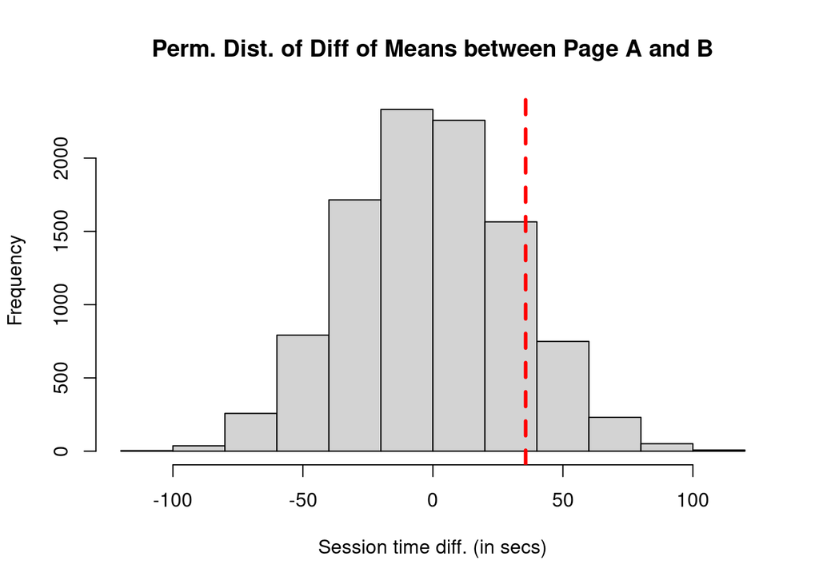

```r
mean_diff_per_permute <- rep(0,10000)

perm_fun <- function(x, nA, nB)
{
  n <- nA + nB
  idx_b <- sample(1:n, nB, replace = FALSE)
  idx_a <- setdiff(1:n, idx_b)
  mean_diff_per_permute <- mean(x[idx_b]) - mean(x[idx_a])
  return(mean_diff_per_permute)
}

for (i in 1:10000){
  mean_diff_per_permute[i] = perm_fun(session_times$Time, 21, 15)
}

hist(mean_diff_per_permute, xlab = 'Session time diff. (in secs)', main = 'Perm. Dist. of Diff of Means between Page A and B')
abline(v = mean_b - mean_a, col = 'red', lty = 2, lwd = 3)
```

```r
(p_value <- mean( mean_diff_per_permute >= mean_b - mean_a ))
```

```
## [1] 0.129
```

- p-value is not rare > 0.05.
- as the prob. of getting our sample or more ext ones is not rare, null hypo seems to be ok
- conc. fail to reject null hypo
- interp. no evidence support to support alt. hypo.

Bootstrap Resampling:

- rep. sample to simulate sampling dist with bootstrap dist

Exhaustive Permutation Resampling:

- A/B test with small sample size
- perm dist doesn’t assume any particular dist for pop dist
- no theoretical pop dist required (dist free, nonparametric)

### Statistical Significance and $p$-Values

**P-Value**:

- assuming there is no effect (null hypo is true) probability of getting as extreme as our sample stat or more extreme ones

**alpha (level of significance)**:

- threshold to determine rarity/unusualness of our sample obs.

**Type I Error**: false positive

- mistakenly concluding there is an effect, when it was a chance outcome

**Type II Error**: false negative

- mistakenly concluding there is no effect, when there was a real effect

**Another permutation resampling example for a web A/B test**

```r
webAB <- tibble(Outcome = c('Conversion','No Conversion'),
                Price_A = c(200,23539),
                Price_B = c(182, 22406))

webAB
```

```
## # A tibble: 2 x 3
##   Outcome       Price_A Price_B
##   <chr>           <dbl>   <dbl>
## 1 Conversion        200     182
## 2 No Conversion   23539   22406
```

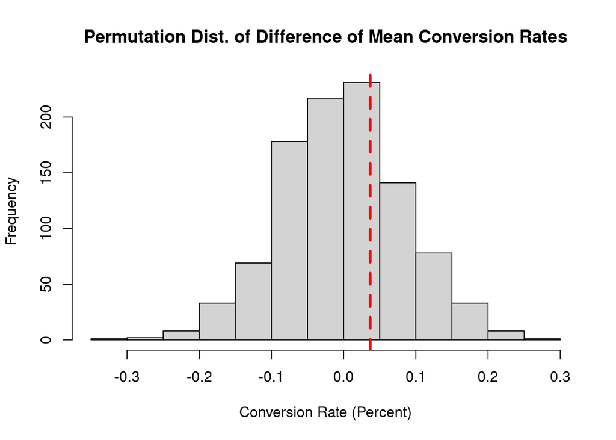

```r
obs_pct_diff <- 100* (200/23739 - 182/22588)
conversion <- c(rep(0,45945), rep(1, 382))

perm_diffs <- rep(0,1000)
for (i in 1:1000){
  perm_diffs[i] = 100 * perm_fun(conversion, 23739,22588)
}

hist(perm_diffs, xlab = 'Conversion Rate (Percent)',
     main = 'Permutation Dist. of Difference of Mean Conversion Rates')
abline(v = obs_pct_diff, col = 'red', lty = 2, lwd = 3)
```

```r
(p_value <- mean( perm_diffs > obs_pct_diff))
```

```
## [1] 0.339
```

- as prob of getting our sample or more extreme ones is very common, h0 seems to be ok
- conc. fail to reject null hypo
- interp. no evidence to support alt. hypo

This can also be tested with a binomial dist with a proportion test:

```r
prop.test( x = c(200, 182), n = c(23739, 22588), alternative = 'greater')
```

```
##
##  2-sample test for equality of proportions with continuity correction
##
## data:  c(200, 182) out of c(23739, 22588)
## X-squared = 0.14893, df = 1, p-value = 0.3498
## alternative hypothesis: greater
## 95 percent confidence interval:
##  -0.001057439  1.000000000
## sample estimates:
##      prop 1      prop 2
## 0.008424955 0.008057376
```

alpha = 0.05 or alpha = 0.1 (level of significance):

- arbitrary
- type I error (false positive) probability
- nhst focuses on alpha, thus on minimizing type I error.

p-value:

- some journals ban use of p-value
- p-hacking, data fishing, data snooping, data dredging, etc.
- for data scientist, it’s a useful metric

### T-Tests

Before wide use of computers, resampling methods were not practical (bootstrap, perm)

By increasing $n$, we are reasonably sure that sampling dist follows a t-distribution

- use t-test/t-interval when sigma is unknown and
  - we know the pop. follows normal dist.
  - $n > 25$ or at least great than or equal to 30 if you want to be conservative
- use t.test()
  - for t-interval, use option of conf.level = 0.95 for example

```r
t.test(session_times$Time[session_times$Page == 'Page B'],
       session_times$Time[session_times$Page == 'Page A'],
       conf.level = 0.95)
```

```
##
##  Welch Two Sample t-test
##
## data:  session_times$Time[session_times$Page == "Page B"] and session_times$Time[session_times$Page == "Page A"]
## t = 1.0983, df = 27.693, p-value = 0.2815
## alternative hypothesis: true difference in means is not equal to 0
## 95 percent confidence interval:
##  -30.88644 102.21978
## sample estimates:
## mean of x mean of y
##  162.0000  126.3333
```